# I Contexte

## Région Europe & Central Asia

```python
Serie=df1.loc['Europe & Central Asia',:].dropna().sort_values(ascending=True)
```

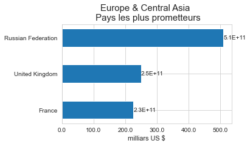

```python
bar1(Serie.tail(3),titre='Europe & Central Asia \n Pays les plus prometteurs',size=(5,3))
```

La Russie est exclue en raison des risques de rencontrer des obstacles pour des raisons politiques.

```python
S1=Serie.drop('Russian Federation')
```

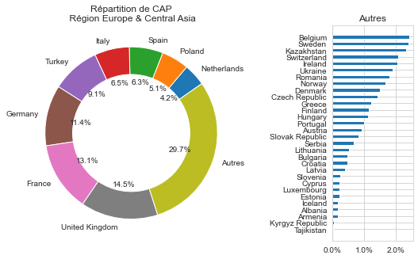

```python
Pie_Autres(S1,titre='Répartition de CAP\n Région Europe & Central Asia',bar=True,part=3)
```

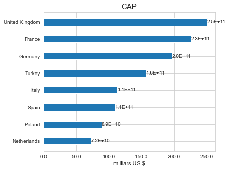

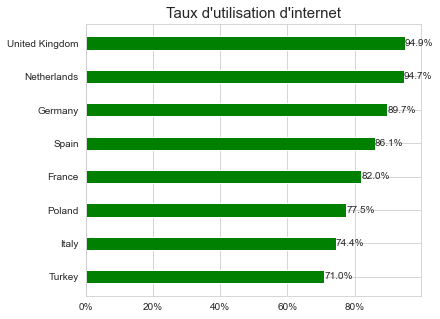

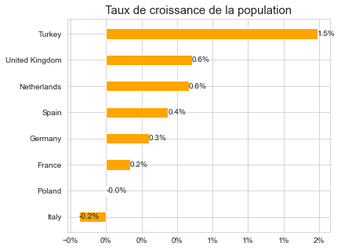

```python
#masque permettant de retenir les noms des n premiers pays du pieplot
mask=DataSet.index.isin(S1.iloc[-8:].index)
width=.4
# Tracé de CAP
bar1(DataSet[mask].sort_values(by='CAP').iloc[:,0],titre='CAP',size=(6,5),width=width)
# Tracé du taux d'utilisation d'internet
bar2(DataSet[mask].sort_values(by='IT.NET.USER.P2').iloc[:,1],titre='Taux d\'utilisation d\'internet',color='green',size=(6,5),width=width)
# Tracé du taux de croissance de la population
bar2(DataSet[mask].sort_values(by='SP.POP.GROW').iloc[:,2],titre='Taux de croissance de la population',color='orange',size=(6,5),width=width)
```

La France apparaît dans ce classement. Je la garde à des fins de comparaison de marché, puisque academy est déjà bien implantée sur ce marché.

Tous les pays ont un taux d'utilisation d'internet supérieur à 70%. La Turquie a la plus forte croissance de population mais le plus mauvais taux d'utilisation d'internet.

Le classement des pays où opérer en priorité est le suivant : Royaume Uni, Allemagne, Espagne, Pays Bas.

## Région Latin America & Caribbean

```python
Serie=df1.loc['Latin America & Caribbean',:].dropna().sort_values(ascending=True)
```

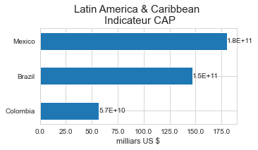

```python
bar1(Serie.tail(3),titre='Latin America & Caribbean \n Indicateur CAP',size=(5,2.5))
```

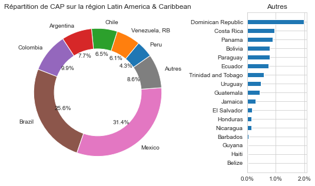

```python
Pie_Autres(Serie,titre='Répartition de CAP sur la région Latin America & Caribbean',part=4,bar=True)
```

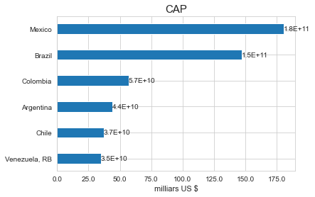

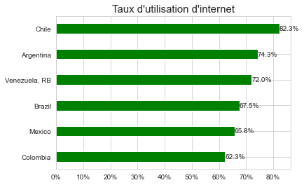

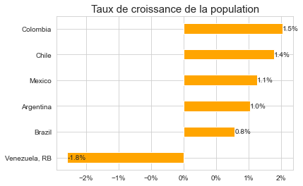

```python
#masque permettant de retenir les noms des n premiers pays du pieplot
mask=DataSet.index.isin(Serie.iloc[-6:].index)
width=.4
# Tracé de CAP
bar1(DataSet[mask].sort_values(by='CAP').iloc[:,0],titre='CAP',size=(6,4),width=width)
# Tracé du taux d'utilisation d'internet
bar2(DataSet[mask].sort_values(by='IT.NET.USER.P2').iloc[:,1],titre='Taux d\'utilisation d\'internet',color='green',size=(6,4),width=width)
# Tracé du taux de croissance de la population
bar2(DataSet[mask].sort_values(by='SP.POP.GROW').iloc[:,2],titre='Taux de croissance de la population',color='orange',size=(6,4),width=width)
```

Le Brésil et le Mexique semblent intéressants.